Github Page: (https://christinacampbell98.github.io)

# Final Tutorial: What is the Impact of Land Use and Forestry on GHG Emissions in the US?

## Import the datasets

For my tutorial, I am interested in exploring Climate Change data. With the recent Climate Change UN Summit, the severity and pressing need for change has never been more apparent. I want to explore some of the datasets that are available and see how they coincide with or challenge the information that is being displayed to the public.

The first data set that I am exploring displays the total GHG emissions produced by state, and also breaks down these emissions by industry. The data set also provides information on each state, such as their total population, GDP, and total energy use. I found this dataset on the World Resources Institute(http://datasets.wri.org), developed by CAIT (Climate Analysis Indicators Tool). With this data set, I want to examine what industry is having the largest impact on the GHG emissions of each region of the US and see if these results are expected or surprising.

```python
import pandas as pd
from pandas import ExcelWriter
from pandas import ExcelFile
%matplotlib inline
import numpy as np
import pandas as pd
data=pd.read_excel("/Users/christinacampbell/Downloads/cait2.0u.s.statesghgemissions-alldata.xlsx",sheet_name="State GHG Emissions")
data.columns=['State',"Year","Total GHG Emissions Excluding LUCF (MtCO2e)","Total GHG Emissions Including LUCF (MtCO2e","Total CO2 (excluding LUCF) (MtCO2e)","Total CH4 (MtCO2e)","Total N2O (MtCO2e)","Total F-Gas (MtCO2e)","Energy (MtCO2e)","Industrial Processes (MtCO2e)","Agriculture (MtCO2e)","Waste (MtCO2e)","Land Use and Forestry (MtCO2e)","Bunker Fuels (MtCO2e)","Electric Power (MtCO2e)","Commercial (MtCO2e)","Residential (MtCO2e","Industrial (MtCO2e","Transportation (MtCO2e)","Fugitive Emissions (MtCO2e)","State GDP (Million US$ (chained 1997/2005))","Population (People)","Total Energy Use (Thous. tonnes oil eq. (ktoe))"]
data=pd.DataFrame(data,columns=['State',"Year","Total GHG Emissions Excluding LUCF (MtCO2e)","Total GHG Emissions Including LUCF (MtCO2e","Total CO2 (excluding LUCF) (MtCO2e)","Total CH4 (MtCO2e)","Total N2O (MtCO2e)","Total F-Gas (MtCO2e)","Energy (MtCO2e)","Industrial Processes (MtCO2e)","Agriculture (MtCO2e)","Waste (MtCO2e)","Land Use and Forestry (MtCO2e)","Bunker Fuels (MtCO2e)","Electric Power (MtCO2e)","Commercial (MtCO2e)","Residential (MtCO2e","Industrial (MtCO2e","Transportation (MtCO2e)","Fugitive Emissions (MtCO2e)","State GDP (Million US$ (chained 1997/2005))","Population (People)","Total Energy Use (Thous. tonnes oil eq. (ktoe))"])
data=data.drop(data.index[0])
data=data.drop(data.index[1])
data= data.drop(data.index[0]).reset_index()
data.head()
```

|  | index | State | Year | Total GHG Emissions Excluding LUCF (MtCO2e) | Total GHG Emissions Including LUCF (MtCO2e | Total CO2 (excluding LUCF) (MtCO2e) | Total CH4 (MtCO2e) | Total N2O (MtCO2e) | Total F-Gas (MtCO2e) | Energy (MtCO2e) | ... | Bunker Fuels (MtCO2e) | Electric Power (MtCO2e) | Commercial (MtCO2e) | Residential (MtCO2e | Industrial (MtCO2e | Transportation (MtCO2e) | Fugitive Emissions (MtCO2e) | State GDP (Million US$ (chained 1997/2005)) | Population (People) | Total Energy Use (Thous. tonnes oil eq. (ktoe)) |
| --- | --- | --- | --- | --- | --- | --- | --- | --- | --- | --- | --- | --- | --- | --- | --- | --- | --- | --- | --- | --- | --- |
| 0 | 3 | Alabama | 1990 | 137.889 | 81.3057 | 112.129 | 20.3764 | 4.78913 | 0.594547 | 125.397 | ... | 0 | 50.5856 | 2.45053 | 3.21186 | 25.4329 | 29.575 | 14.1415 | 83766 | 4050055 | 41971 |
| 1 | 4 | Alaska | 1990 | 45.4933 | 14.1738 | 35.8776 | 9.30383 | 0.269331 | 0.0425567 | 44.024 | ... | 0 | 2.61091 | 2.20804 | 1.60736 | 15.8435 | 12.2986 | 9.45562 | 28772 | 553290 | 14718.6 |
| 2 | 5 | Arizona | 1990 | 70.3445 | 77.2725 | 63.2755 | 3.45763 | 2.81589 | 0.795469 | 64.5135 | ... | 0 | 32.6838 | 1.91184 | 1.89047 | 3.88477 | 24.0605 | 0.0821269 | 81606 | 3684097 | 23661.8 |
| 3 | 6 | Arkansas | 1990 | 66.9749 | 21.0251 | 52.1941 | 7.73925 | 6.7694 | 0.272173 | 52.9544 | ... | 0 | 21.699 | 1.628 | 2.55221 | 9.47997 | 16.8803 | 0.714961 | 44496 | 2356586 | 21569.3 |
| 4 | 7 | California | 1990 | 420.741 | 391.51 | 368.596 | 30.7299 | 18.7054 | 2.70968 | 378.354 | ... | 0 | 40.3034 | 19.0688 | 30.0707 | 71.9105 | 212.485 | 4.5154 | 906103 | 29959515 | 187616 |

5 rows × 24 columns

```python
data.shape
```

```
(1144, 24)
```

The second data set that I am considering is also from the World Resources Institute, and was developed by CAIT. This data set shows GHG emissions (with and without land-use change and forestry), as well as fossil fuel emissions for almost every country. This dataset also includes data on each countries GDP and population. The unique aspect of this data set is that it includes predictive data, that extends all the way into 2050. The dataset predicts not only where GHG emissions will be if each country continues down their current path, but also predicts where the country would be if they followed a policy scenario to change their behavior. The policies that are chosen are described in the dataset, and are based off of proposed policies within the countries.

I will use this dataset to compare the GHG emissions of each region to the total GHG emissions of the US. I will first import the data, then I will drop the unessary columns and change the column names approriately.

```python
data2=pd.read_excel("/Users/christinacampbell/Downloads/caitprojectionsalldata4-9-150 (1).xlsx",sheet_name="GHG Emissions Data")
data2=data2.drop(['Unnamed: 1','Unnamed: 2','Unnamed: 6','Unnamed: 7','Unnamed: 8','Unnamed: 9'],axis=1)
data2.columns=['region','Year','Total GHG Emissions Excluding LUCF (MtCO2e)','Total GHG Emissions Including LUCF (MtCO2e']
data2=pd.DataFrame(data2,columns=['region','Year','Total GHG Emissions Including LUCF (MtCO2e','Total GHG Emissions Excluding LUCF (MtCO2e)'])
data2=data2.drop([0])
```

```python
data2.head()
```

|  | region | Year | Total GHG Emissions Including LUCF (MtCO2e | Total GHG Emissions Excluding LUCF (MtCO2e) |
| --- | --- | --- | --- | --- |
| 1 | Australia | 1990 | 416.1 | 516.74 |
| 2 | Australia | 1995 | 439.48 | 470.59 |
| 3 | Australia | 2000 | 494.27 | 529.64 |
| 4 | Australia | 2005 | 527.76 | 572.43 |
| 5 | Australia | 2010 | 542.69 | 558.49 |

Now that I have the data in the format that I want, I wil drop all data that is not for the US, and all values of NA.

```python
data2=data2[data2['region']=='United States']
```

```python
data2=data2.dropna()
```

```python
data2
```

|  | region | Year | Total GHG Emissions Including LUCF (MtCO2e | Total GHG Emissions Excluding LUCF (MtCO2e) |
| --- | --- | --- | --- | --- |
| 104 | United States | 2000 | 7076 | 6395 |
| 105 | United States | 2005 | 7195 | 6197 |
| 106 | United States | 2010 | 6812 | 5923 |
| 107 | United States | 2011 | 6702 | 5797 |
| 108 | United States | 2015 | 6643 | 5759 |
| 109 | United States | 2020 | 6815 | 5918 |
| 110 | United States | 2025 | 6967 | 6050 |
| 111 | United States | 2030 | 7041 | 6104 |

## Process and Tidy Dataset 1

For my tutorial, I will be focusing primarily on comparing the emmissions from different industries in different regions, but I want to keep this information more generalized in order to see the bigger picture. Thus, I can drop the columns that show data about sub-sectors.

```python
data=data.drop(['Electric Power (MtCO2e)','Commercial (MtCO2e)','Residential (MtCO2e','Industrial (MtCO2e','Transportation (MtCO2e)','Fugitive Emissions (MtCO2e)'],axis=1)
data.head()
```

|  | index | State | Year | Total GHG Emissions Excluding LUCF (MtCO2e) | Total GHG Emissions Including LUCF (MtCO2e | Total CO2 (excluding LUCF) (MtCO2e) | Total CH4 (MtCO2e) | Total N2O (MtCO2e) | Total F-Gas (MtCO2e) | Energy (MtCO2e) | Industrial Processes (MtCO2e) | Agriculture (MtCO2e) | Waste (MtCO2e) | Land Use and Forestry (MtCO2e) | Bunker Fuels (MtCO2e) | State GDP (Million US$ (chained 1997/2005)) | Population (People) | Total Energy Use (Thous. tonnes oil eq. (ktoe)) |
| --- | --- | --- | --- | --- | --- | --- | --- | --- | --- | --- | --- | --- | --- | --- | --- | --- | --- | --- |
| 0 | 3 | Alabama | 1990 | 137.889 | 81.3057 | 112.129 | 20.3764 | 4.78913 | 0.594547 | 125.397 | 3.51822 | 5.6312 | 3.34175 | -56.5829 | 0 | 83766 | 4050055 | 41971 |
| 1 | 4 | Alaska | 1990 | 45.4933 | 14.1738 | 35.8776 | 9.30383 | 0.269331 | 0.0425567 | 44.024 | 1.09924 | 0.0462487 | 0.323831 | -31.3195 | 0 | 28772 | 553290 | 14718.6 |
| 2 | 5 | Arizona | 1990 | 70.3445 | 77.2725 | 63.2755 | 3.45763 | 2.81589 | 0.795469 | 64.5135 | 1.12535 | 3.38128 | 1.32434 | 6.92798 | 0 | 81606 | 3684097 | 23661.8 |
| 3 | 6 | Arkansas | 1990 | 66.9749 | 21.0251 | 52.1941 | 7.73925 | 6.7694 | 0.272173 | 52.9544 | 1.18757 | 11.2791 | 1.5538 | -45.9498 | 0 | 44496 | 2356586 | 21569.3 |
| 4 | 7 | California | 1990 | 420.741 | 391.51 | 368.596 | 30.7299 | 18.7054 | 2.70968 | 378.354 | 7.88305 | 21.4835 | 13.0199 | -29.2304 | 0 | 906103 | 29959515 | 187616 |

I will now make the data more tidy, by combining the data that expresses the specific sector emmissions, and the specific gas type emmissions into one column. I will do this using the melt method.

```python
id_vars=['index','State','Year','Total GHG Emissions Excluding LUCF (MtCO2e)','Total GHG Emissions Including LUCF (MtCO2e','Total CO2 (excluding LUCF) (MtCO2e)','Total CH4 (MtCO2e)','Total N2O (MtCO2e)','Total F-Gas (MtCO2e)',
         'State GDP (Million US$ (chained 1997/2005))','Population (People)','Total Energy Use (Thous. tonnes oil eq. (ktoe))'
]
data=pd.melt(frame=data,
             id_vars=id_vars,
             var_name="sector",
            value_name='MtCO2e emmisions by sector')
data.head()
```

|  | index | State | Year | Total GHG Emissions Excluding LUCF (MtCO2e) | Total GHG Emissions Including LUCF (MtCO2e | Total CO2 (excluding LUCF) (MtCO2e) | Total CH4 (MtCO2e) | Total N2O (MtCO2e) | Total F-Gas (MtCO2e) | State GDP (Million US$ (chained 1997/2005)) | Population (People) | Total Energy Use (Thous. tonnes oil eq. (ktoe)) | sector | MtCO2e emmisions by sector |
| --- | --- | --- | --- | --- | --- | --- | --- | --- | --- | --- | --- | --- | --- | --- |
| 0 | 3 | Alabama | 1990 | 137.889 | 81.3057 | 112.129 | 20.3764 | 4.78913 | 0.594547 | 83766 | 4050055 | 41971 | Energy (MtCO2e) | 125.397 |
| 1 | 4 | Alaska | 1990 | 45.4933 | 14.1738 | 35.8776 | 9.30383 | 0.269331 | 0.0425567 | 28772 | 553290 | 14718.6 | Energy (MtCO2e) | 44.024 |
| 2 | 5 | Arizona | 1990 | 70.3445 | 77.2725 | 63.2755 | 3.45763 | 2.81589 | 0.795469 | 81606 | 3684097 | 23661.8 | Energy (MtCO2e) | 64.5135 |
| 3 | 6 | Arkansas | 1990 | 66.9749 | 21.0251 | 52.1941 | 7.73925 | 6.7694 | 0.272173 | 44496 | 2356586 | 21569.3 | Energy (MtCO2e) | 52.9544 |
| 4 | 7 | California | 1990 | 420.741 | 391.51 | 368.596 | 30.7299 | 18.7054 | 2.70968 | 906103 | 29959515 | 187616 | Energy (MtCO2e) | 378.354 |

```python
id_vars2=['index','State','Year','Total GHG Emissions Excluding LUCF (MtCO2e)','Total GHG Emissions Including LUCF (MtCO2e','sector','MtCO2e emmisions by sector',
         'State GDP (Million US$ (chained 1997/2005))','Population (People)','Total Energy Use (Thous. tonnes oil eq. (ktoe))']
data=pd.melt(frame=data,
             id_vars=id_vars2,
             var_name="gas",
            value_name='total emmisions by gas')
```

```python
data.head()
```

|  | index | State | Year | Total GHG Emissions Excluding LUCF (MtCO2e) | Total GHG Emissions Including LUCF (MtCO2e | sector | MtCO2e emmisions by sector | State GDP (Million US$ (chained 1997/2005)) | Population (People) | Total Energy Use (Thous. tonnes oil eq. (ktoe)) | gas | total emmisions by gas |
| --- | --- | --- | --- | --- | --- | --- | --- | --- | --- | --- | --- | --- |
| 0 | 3 | Alabama | 1990 | 137.889 | 81.3057 | Energy (MtCO2e) | 125.397 | 83766 | 4050055 | 41971 | Total CO2 (excluding LUCF) (MtCO2e) | 112.129 |
| 1 | 4 | Alaska | 1990 | 45.4933 | 14.1738 | Energy (MtCO2e) | 44.024 | 28772 | 553290 | 14718.6 | Total CO2 (excluding LUCF) (MtCO2e) | 35.8776 |
| 2 | 5 | Arizona | 1990 | 70.3445 | 77.2725 | Energy (MtCO2e) | 64.5135 | 81606 | 3684097 | 23661.8 | Total CO2 (excluding LUCF) (MtCO2e) | 63.2755 |
| 3 | 6 | Arkansas | 1990 | 66.9749 | 21.0251 | Energy (MtCO2e) | 52.9544 | 44496 | 2356586 | 21569.3 | Total CO2 (excluding LUCF) (MtCO2e) | 52.1941 |
| 4 | 7 | California | 1990 | 420.741 | 391.51 | Energy (MtCO2e) | 378.354 | 906103 | 29959515 | 187616 | Total CO2 (excluding LUCF) (MtCO2e) | 368.596 |

Next, I will convert the data types of the columns appropriatly.

```python
data['Total GHG Emissions Excluding LUCF (MtCO2e)']=pd.to_numeric(data['Total GHG Emissions Excluding LUCF (MtCO2e)'])
data['Total GHG Emissions Including LUCF (MtCO2e']=pd.to_numeric(data['Total GHG Emissions Including LUCF (MtCO2e'])
data['MtCO2e emmisions by sector']=pd.to_numeric(data['MtCO2e emmisions by sector'])
data['total emmisions by gas']=pd.to_numeric(data['total emmisions by gas'])
data['State GDP (Million US$ (chained 1997/2005))']=pd.to_numeric(data['State GDP (Million US$ (chained 1997/2005))'])
data['Population (People)']=pd.to_numeric(data['Population (People)'])
data['Total Energy Use (Thous. tonnes oil eq. (ktoe))']=pd.to_numeric(data['Total Energy Use (Thous. tonnes oil eq. (ktoe))'])
data['Year']=pd.to_numeric(data['Year'])
data=data.drop('index',axis=1)
```

## Turn the State Data into Region Data

Instead of analyzing the data by state, we want to analyze it by regions. in order to do this, I will separate and group the data into regions based off of their states. I created a separate dataframe for each region, and then recombined them once I create and assign a column called "region".

```python
Northeast=data[(data['State']=="Main") |(data['State']=="New York" )| (data['State']== "New Jersey") | (data['State']=="Vermont" )| (data['State']=="Massachusets") | (data['State']=="Rhode Island") | (data['State']=="Conneticut" )| (data['State']=="New Hampshire") | (data['State']=="Pennsylvania")|(data['State']=="Maryland")] .reset_index()
Northeast['region']='northeast'
Northeast=Northeast.drop(['State'],axis=1)
Northeast.head()
```

|  | index | Year | Total GHG Emissions Excluding LUCF (MtCO2e) | Total GHG Emissions Including LUCF (MtCO2e | sector | MtCO2e emmisions by sector | State GDP (Million US$ (chained 1997/2005)) | Population (People) | Total Energy Use (Thous. tonnes oil eq. (ktoe)) | gas | total emmisions by gas | region |
| --- | --- | --- | --- | --- | --- | --- | --- | --- | --- | --- | --- | --- |
| 0 | 20 | 1990 | 79.905796 | 77.408280 | Energy (MtCO2e) | 72.485691 | 136165 | 4799770 | 31977.45708 | Total CO2 (excluding LUCF) (MtCO2e) | 71.931167 | northeast |
| 1 | 29 | 1990 | 15.737613 | 10.902850 | Energy (MtCO2e) | 15.021075 | 27259 | 1112384 | 6739.75292 | Total CO2 (excluding LUCF) (MtCO2e) | 14.681697 | northeast |
| 2 | 30 | 1990 | 120.199795 | 109.795573 | Energy (MtCO2e) | 113.397511 | 253360 | 7762963 | 56593.73967 | Total CO2 (excluding LUCF) (MtCO2e) | 111.462115 | northeast |
| 3 | 32 | 1990 | 233.803453 | 220.332967 | Energy (MtCO2e) | 212.715571 | 595908 | 18020784 | 94132.16384 | Total CO2 (excluding LUCF) (MtCO2e) | 209.793924 | northeast |
| 4 | 38 | 1990 | 298.480702 | 275.367345 | Energy (MtCO2e) | 281.150013 | 288955 | 11903299 | 91627.90546 | Total CO2 (excluding LUCF) (MtCO2e) | 268.946929 | northeast |

```python
Southeast=data[(data['State']=="Alabama") |(data['State']=="Florida" )| (data['State']== "Georgia") | (data['State']=="Kentucky" )| (data['State']=="Mississippi") | (data['State']=="North Carolina") | (data['State']=="South Carolina" )| (data['State']=="Tennessee") |(data['State']=="Virginia")|(data['State']=="West Virginia")|(data['State']=="Arkansas")|(data['State']=="Louisiana")|(data['State']=="Delaware")] .reset_index()
Southeast['region']='southeast'
Southeast=Southeast.drop(['State'],axis=1)
Southeast.head()
```

|  | index | Year | Total GHG Emissions Excluding LUCF (MtCO2e) | Total GHG Emissions Including LUCF (MtCO2e | sector | MtCO2e emmisions by sector | State GDP (Million US$ (chained 1997/2005)) | Population (People) | Total Energy Use (Thous. tonnes oil eq. (ktoe)) | gas | total emmisions by gas | region |
| --- | --- | --- | --- | --- | --- | --- | --- | --- | --- | --- | --- | --- |
| 0 | 0 | 1990 | 137.888617 | 81.305733 | Energy (MtCO2e) | 125.397445 | 83766 | 4050055 | 41970.979410 | Total CO2 (excluding LUCF) (MtCO2e) | 112.128509 | southeast |
| 1 | 3 | 1990 | 66.974876 | 21.025058 | Energy (MtCO2e) | 52.954443 | 44496 | 2356586 | 21569.300910 | Total CO2 (excluding LUCF) (MtCO2e) | 52.194051 | southeast |
| 2 | 7 | 1990 | 19.042026 | 19.320112 | Energy (MtCO2e) | 17.986728 | 25887 | 669567 | 6437.055599 | Total CO2 (excluding LUCF) (MtCO2e) | 17.844128 | southeast |
| 3 | 9 | 1990 | 210.033368 | 219.555860 | Energy (MtCO2e) | 191.339682 | 304324 | 13033307 | 82688.053050 | Total CO2 (excluding LUCF) (MtCO2e) | 189.418217 | southeast |
| 4 | 10 | 1990 | 151.334129 | 108.539070 | Energy (MtCO2e) | 141.517374 | 165062 | 6512602 | 56187.598080 | Total CO2 (excluding LUCF) (MtCO2e) | 139.392909 | southeast |

```python
Northwest=data[(data['State']=="Oregon") |(data['State']=="Washington" )| (data['State']== "Idaho") | (data['State']=="Wyoming" )| (data['State']=="Montana")] .reset_index()
Northwest['region']='northwest'
Northwest=Northwest.drop(['State'],axis=1)
Northwest.head()
```

|  | index | Year | Total GHG Emissions Excluding LUCF (MtCO2e) | Total GHG Emissions Including LUCF (MtCO2e | sector | MtCO2e emmisions by sector | State GDP (Million US$ (chained 1997/2005)) | Population (People) | Total Energy Use (Thous. tonnes oil eq. (ktoe)) | gas | total emmisions by gas | region |
| --- | --- | --- | --- | --- | --- | --- | --- | --- | --- | --- | --- | --- |
| 0 | 12 | 1990 | 18.915797 | -16.207316 | Energy (MtCO2e) | 11.816223 | 20161 | 1012384 | 10216.261390 | Total CO2 (excluding LUCF) (MtCO2e) | 11.772727 | northwest |
| 1 | 26 | 1990 | 37.961805 | -31.020367 | Energy (MtCO2e) | 30.340779 | 15355 | 800204 | 8758.138255 | Total CO2 (excluding LUCF) (MtCO2e) | 28.695920 | northwest |
| 2 | 37 | 1990 | 39.449523 | -48.112014 | Energy (MtCO2e) | 32.207869 | 64881 | 2860375 | 24650.226420 | Total CO2 (excluding LUCF) (MtCO2e) | 31.282144 | northwest |
| 3 | 47 | 1990 | 85.396670 | 43.970095 | Energy (MtCO2e) | 74.228496 | 141946 | 4903043 | 51571.867120 | Total CO2 (excluding LUCF) (MtCO2e) | 72.540246 | northwest |
| 4 | 50 | 1990 | 72.035105 | 57.527740 | Energy (MtCO2e) | 69.728641 | 13673 | 453690 | 10065.492320 | Total CO2 (excluding LUCF) (MtCO2e) | 61.405931 | northwest |

```python
Midwest=data[(data['State']=="Illinois") |(data['State']=="Indiana" )| (data['State']== "Iowa") | (data['State']=="Kansas" )| (data['State']=="Michigan")|(data['State']=="Minnesota")|(data['State']=="Missouri")|(data['State']=="North Dakota")|(data['State']=="South Dekota")|(data['State']=="Ohio")|(data['State']=="Wisconsin")] .reset_index()
Midwest['region']='midwest'
Midwest=Midwest.drop(['State'],axis=1)
Midwest.head()
```

|  | index | Year | Total GHG Emissions Excluding LUCF (MtCO2e) | Total GHG Emissions Including LUCF (MtCO2e | sector | MtCO2e emmisions by sector | State GDP (Million US$ (chained 1997/2005)) | Population (People) | Total Energy Use (Thous. tonnes oil eq. (ktoe)) | gas | total emmisions by gas | region |
| --- | --- | --- | --- | --- | --- | --- | --- | --- | --- | --- | --- | --- |
| 0 | 13 | 1990 | 234.264978 | 224.283614 | Energy (MtCO2e) | 201.291462 | 324012 | 11453316 | 90244.07068 | Total CO2 (excluding LUCF) (MtCO2e) | 195.496541 | midwest |
| 1 | 14 | 1990 | 227.977405 | 214.146802 | Energy (MtCO2e) | 208.930041 | 128197 | 5557798 | 62807.60261 | Total CO2 (excluding LUCF) (MtCO2e) | 207.404311 | midwest |
| 2 | 15 | 1990 | 96.491244 | 88.053097 | Energy (MtCO2e) | 65.009762 | 63460 | 2781018 | 23835.54929 | Total CO2 (excluding LUCF) (MtCO2e) | 65.607835 | midwest |
| 3 | 16 | 1990 | 96.087576 | 85.876650 | Energy (MtCO2e) | 74.657781 | 60672 | 2481349 | 26874.24030 | Total CO2 (excluding LUCF) (MtCO2e) | 72.081673 | midwest |
| 4 | 22 | 1990 | 202.554763 | 148.267445 | Energy (MtCO2e) | 183.520225 | 229534 | 9311319 | 72426.38203 | Total CO2 (excluding LUCF) (MtCO2e) | 181.947154 | midwest |

```python
Southwest=data[(data['State']=="New Mexico")|(data['State']=="Arizona")|(data['State']=="Texas")|(data['State']=="Oklahoma")] .reset_index()
Southwest['region']='southwest'
Southwest=Southwest.drop(['State'],axis=1)
Southwest.head()
```

|  | index | Year | Total GHG Emissions Excluding LUCF (MtCO2e) | Total GHG Emissions Including LUCF (MtCO2e | sector | MtCO2e emmisions by sector | State GDP (Million US$ (chained 1997/2005)) | Population (People) | Total Energy Use (Thous. tonnes oil eq. (ktoe)) | gas | total emmisions by gas | region |
| --- | --- | --- | --- | --- | --- | --- | --- | --- | --- | --- | --- | --- |
| 0 | 2 | 1990 | 70.344474 | 77.272454 | Energy (MtCO2e) | 64.513508 | 81606 | 3684097 | 23661.77300 | Total CO2 (excluding LUCF) (MtCO2e) | 63.275484 | southwest |
| 1 | 31 | 1990 | 62.767553 | 57.307337 | Energy (MtCO2e) | 57.713747 | 28714 | 1521574 | 15030.26262 | Total CO2 (excluding LUCF) (MtCO2e) | 53.021372 | southwest |
| 2 | 36 | 1990 | 115.379625 | 106.404779 | Energy (MtCO2e) | 96.481862 | 67083 | 3148825 | 34847.15973 | Total CO2 (excluding LUCF) (MtCO2e) | 91.800397 | southwest |
| 3 | 43 | 1990 | 691.978385 | 676.913922 | Energy (MtCO2e) | 633.980408 | 437292 | 17056755 | 259690.58890 | Total CO2 (excluding LUCF) (MtCO2e) | 612.285944 | southwest |
| 4 | 54 | 1991 | 71.754660 | 78.681823 | Energy (MtCO2e) | 65.373325 | 81946 | 3788576 | 23807.09896 | Total CO2 (excluding LUCF) (MtCO2e) | 64.642897 | southwest |

```python
region_data=Northeast.merge(Southeast, how='outer')
region_data=region_data.merge(Northwest, how='outer')
region_data=region_data.merge(Midwest, how='outer')
region_data=region_data.merge(Southwest, how='outer')
region_data=region_data.drop(['index'],axis=1)
```

```python
region_data.shape
```

```
(20592, 11)
```

Now, I want to aggregate the data of the numerical columns, so that there is one row for each combination of region, year, sector, and gas emmission type. I will use the sum aggregation function in order to get the total emissions for each region.

```python
region_data=region_data.groupby(['region','Year','sector','gas']).agg({'Total GHG Emissions Excluding LUCF (MtCO2e)':'sum','Total GHG Emissions Including LUCF (MtCO2e':'sum','MtCO2e emmisions by sector':'sum','State GDP (Million US$ (chained 1997/2005))':'sum','Population (People)':'sum','Total Energy Use (Thous. tonnes oil eq. (ktoe))':'sum','total emmisions by gas':'sum'})
region_data=region_data.reset_index()
region_data.head()
```

|  | region | Year | sector | gas | Total GHG Emissions Excluding LUCF (MtCO2e) | Total GHG Emissions Including LUCF (MtCO2e | MtCO2e emmisions by sector | State GDP (Million US$ (chained 1997/2005)) | Population (People) | Total Energy Use (Thous. tonnes oil eq. (ktoe)) | total emmisions by gas |
| --- | --- | --- | --- | --- | --- | --- | --- | --- | --- | --- | --- |
| 0 | midwest | 1990 | Agriculture (MtCO2e) | Total CH4 (MtCO2e) | 1521.534389 | 1377.340495 | 146.50876 | 1441985 | 57509946 | 489191.907914 | 115.472189 |
| 1 | midwest | 1990 | Agriculture (MtCO2e) | Total CO2 (excluding LUCF) (MtCO2e) | 1521.534389 | 1377.340495 | 146.50876 | 1441985 | 57509946 | 489191.907914 | 1283.189128 |
| 2 | midwest | 1990 | Agriculture (MtCO2e) | Total F-Gas (MtCO2e) | 1521.534389 | 1377.340495 | 146.50876 | 1441985 | 57509946 | 489191.907914 | 7.603820 |
| 3 | midwest | 1990 | Agriculture (MtCO2e) | Total N2O (MtCO2e) | 1521.534389 | 1377.340495 | 146.50876 | 1441985 | 57509946 | 489191.907914 | 115.269251 |
| 4 | midwest | 1990 | Bunker Fuels (MtCO2e) | Total CH4 (MtCO2e) | 1521.534389 | 1377.340495 | 0.00000 | 1441985 | 57509946 | 489191.907914 | 115.472189 |

# Analysis

### Question 1: What is the impact of LUCF on each region?

First, I want to compare the emissions with and without LUCF in each region.

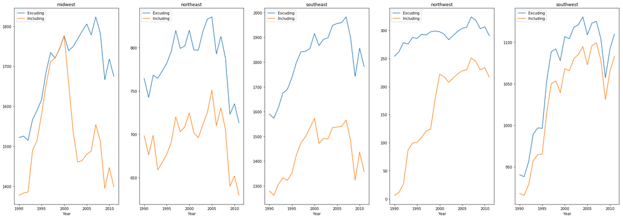

```python
fig, ax = plt.subplots(1, 5, figsize=(30,10))
groups=region_data.groupby('region')
groups.get_group('midwest').plot.line(x='Year',y='Total GHG Emissions Excluding LUCF (MtCO2e)',ax=ax[0], label='Excuding',title='midwest')
groups.get_group('midwest').plot.line(x='Year',y='Total GHG Emissions Including LUCF (MtCO2e',ax=ax[0], label='Including')
groups.get_group('northeast').plot.line(x='Year',y='Total GHG Emissions Excluding LUCF (MtCO2e)',ax=ax[1], label='Excuding',title='northeast')
groups.get_group('northeast').plot.line(x='Year',y='Total GHG Emissions Including LUCF (MtCO2e',ax=ax[1], label='Including')
groups.get_group('southeast').plot.line(x='Year',y='Total GHG Emissions Excluding LUCF (MtCO2e)',ax=ax[2], label='Excuding',title='southeast')
groups.get_group('southeast').plot.line(x='Year',y='Total GHG Emissions Including LUCF (MtCO2e',ax=ax[2], label='Including')
groups.get_group('northwest').plot.line(x='Year',y='Total GHG Emissions Excluding LUCF (MtCO2e)',ax=ax[3], label='Excuding',title='northwest')
groups.get_group('northwest').plot.line(x='Year',y='Total GHG Emissions Including LUCF (MtCO2e',ax=ax[3], label='Including')
groups.get_group('southwest').plot.line(x='Year',y='Total GHG Emissions Excluding LUCF (MtCO2e)',ax=ax[4], label='Excuding',title='southwest')
groups.get_group('southwest').plot.line(x='Year',y='Total GHG Emissions Including LUCF (MtCO2e',ax=ax[4], label='Including')
```

Next, I want to compare the GHG emissions of the regions to each other.

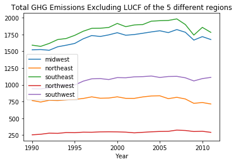

```python
import matplotlib.pyplot as plt
ax=plt.gca()
groups=region_data.groupby('region')
groups.get_group('midwest').plot.line(x='Year',y='Total GHG Emissions Excluding LUCF (MtCO2e)',ax=ax, label='midwest')
groups.get_group('northeast').plot.line(x='Year',y='Total GHG Emissions Excluding LUCF (MtCO2e)',ax=ax,label='northeast')
groups.get_group('southeast').plot.line(x='Year',y='Total GHG Emissions Excluding LUCF (MtCO2e)',ax=ax,label='southeast')
groups.get_group('northwest').plot.line(x='Year',y='Total GHG Emissions Excluding LUCF (MtCO2e)',ax=ax, label='northwest')
groups.get_group('southwest').plot.line(x='Year',y='Total GHG Emissions Excluding LUCF (MtCO2e)',ax=ax,label='southwest',title='Total GHG Emissions Excluding LUCF of the 5 different regions')
```

The line graph below shows a comparison of the Total GHG Emissions Including LUCF of the 5 different regions.

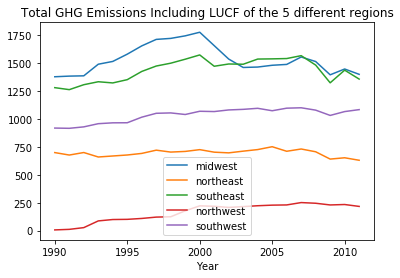

```python
ax=plt.gca()
groups=region_data.groupby('region')
groups.get_group('midwest').plot.line(x='Year',y='Total GHG Emissions Including LUCF (MtCO2e',ax=ax, label='midwest')
groups.get_group('northeast').plot.line(x='Year',y='Total GHG Emissions Including LUCF (MtCO2e',ax=ax,label='northeast')
groups.get_group('southeast').plot.line(x='Year',y='Total GHG Emissions Including LUCF (MtCO2e',ax=ax,label='southeast')
groups.get_group('northwest').plot.line(x='Year',y='Total GHG Emissions Including LUCF (MtCO2e',ax=ax, label='northwest')
groups.get_group('southwest').plot.line(x='Year',y='Total GHG Emissions Including LUCF (MtCO2e',ax=ax,label='southwest',title='Total GHG Emissions Including LUCF of the 5 different regions')
```

### Question 2: What industries are contributing the most to the GHG emissions in each region?

Now, that we have done some analysis on the total GHG emissions in each region, I want to evaluate what industry sectors are having the largest effect on each region.

```python
region_Year_sector=region_data.drop(["gas","Total GHG Emissions Excluding LUCF (MtCO2e)","Total GHG Emissions Including LUCF (MtCO2e","State GDP (Million US$ (chained 1997/2005))","Population (People)","Total Energy Use (Thous. tonnes oil eq. (ktoe))","total emmisions by gas"],axis=1)
region_Year_sector=region_Year_sector.groupby(['region','sector']).agg({'MtCO2e emmisions by sector':'mean'}).reset_index()
region_Year_sector.head()
```

|  | region | sector | MtCO2e emmisions by sector |
| --- | --- | --- | --- |
| 0 | midwest | Agriculture (MtCO2e) | 159.680978 |
| 1 | midwest | Bunker Fuels (MtCO2e) | 0.000982 |
| 2 | midwest | Energy (MtCO2e) | 1431.448447 |
| 3 | midwest | Industrial Processes (MtCO2e) | 65.004013 |
| 4 | midwest | Land Use and Forestry (MtCO2e) | -161.851542 |

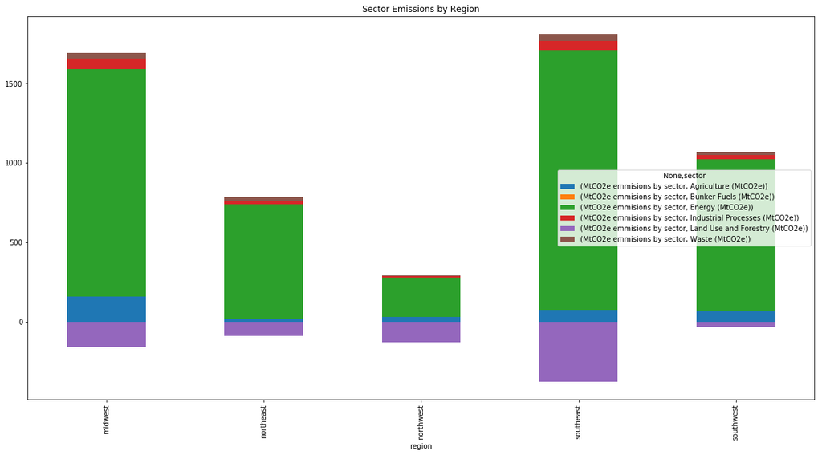

```python
region_Year_sector.pivot_table(index='region',columns='sector').plot.bar(stacked=True,figsize=(20,10), title='Sector Emissions by Region')
```

It is also clear that Energy is substantially the largest source of the emissions in each region. Since we are trying to analyze the differences in each region, lets look at this same plot without Energy contributing as well. This will let us see what industries are uniquely having impacts in the different regions.

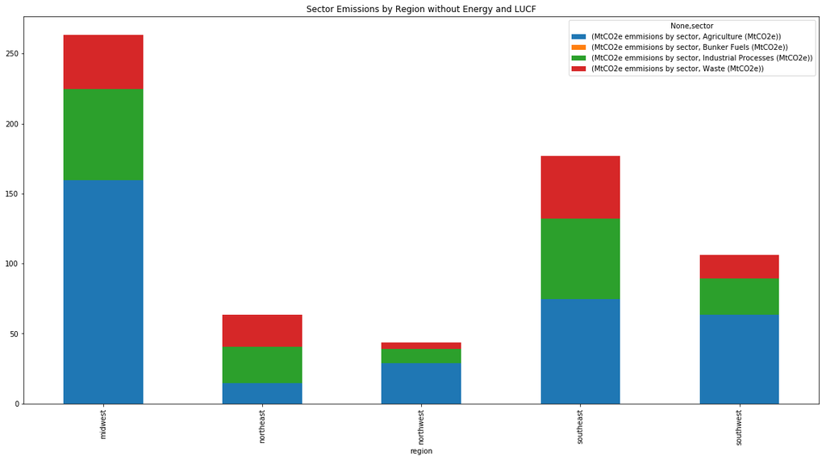

```python
region_Year_sector[(region_Year_sector['sector']!= 'Land Use and Forestry (MtCO2e)') &(region_Year_sector['sector']!= 'Energy (MtCO2e)')].pivot_table(index='region',columns='sector').plot.bar(stacked=True,figsize=(20,10), title='Sector Emissions by Region without Energy and LUCF')
```

We can now more clearly see what industries are impacting each region. For the midwest, northwest, and southwest, the largest contributor is Agriculture while in the northeast Industrial processes is the main contributors. The southeast appears to have an almost even amount of emissions coming from Industrial processes and Agriculture. Something important to note is that the regions with a large contribution of emissions from Agriculture (midwest and southeast) have the higher amount of emissions in general. This is an idea we are going to explore further below.

Below is a different form of a graph in order to visualize the comparisons of emissions by industry sector in the different regions. This will allows us to see what industry is consistently producing the most emissions across the different regions.

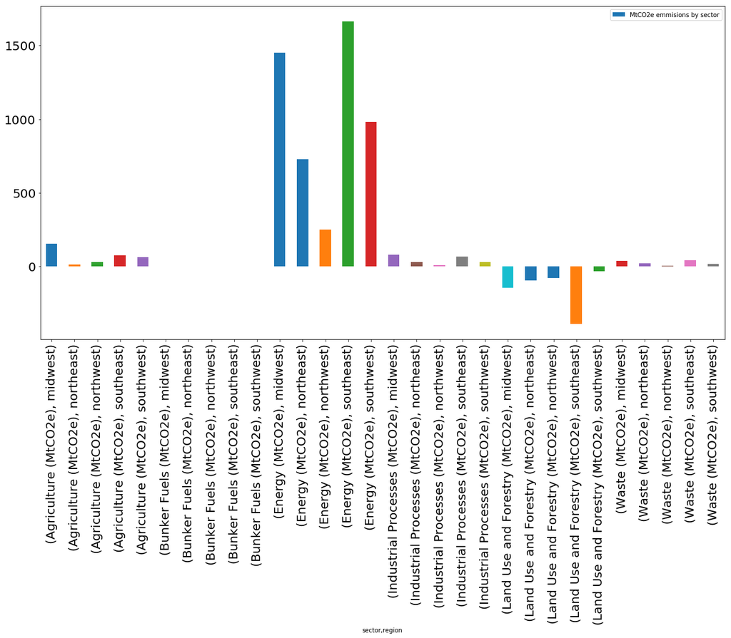

```python
region_data.groupby(['sector','region']).median().plot.bar(y='MtCO2e emmisions by sector',figsize=(20,10),fontsize=20,stacked=True)
```

### Question 3: Is there a correlation between population and Total GHG emissions in each region?

I now want to see if there is a correlation between the Total GHG Emissions Excluding LUCF and total population, in order to determine if the population size has any relation to the GHG emissions in each region. I decided to use the data excluding LUCF in order to analyze all of the GHG emissions being produced, without some being processed by plants. My hypothesis is that there will be a strong positive correlation.

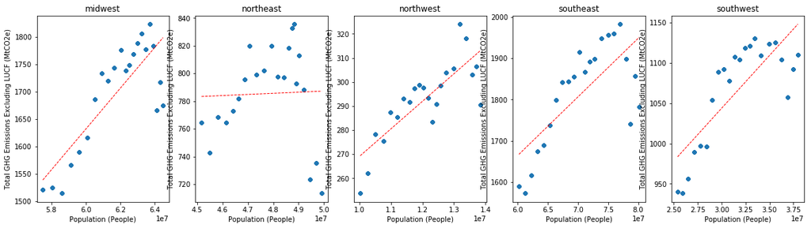

```python
from scipy import stats

fig, ax = plt.subplots(1, 5, figsize=(20,5))
regions= region_data.region.unique()
i=0
for r in regions:
    data=region_data[region_data.region==r]
    data.plot.scatter(x='Population (People)', y='Total GHG Emissions Excluding LUCF (MtCO2e)', ax=ax[i],title=r)
    slope, intercept, r_value, p_value, std_err = stats.linregress(data['Population (People)'],data['Total GHG Emissions Excluding LUCF (MtCO2e)'])
    line = slope *data['Population (People)']  + intercept
    ax[i].plot(data['Population (People)'], line, lw=1, ls='--', color='red')
    i+=1
```

I will first make a new dataframe with the region data normalized, and then will provide some of the same graphs as above for interpretation and comparison.

```python
 norm=region_data[['Total GHG Emissions Excluding LUCF (MtCO2e)','Total GHG Emissions Including LUCF (MtCO2e','MtCO2e emmisions by sector']].div(region_data['Population (People)'],axis=0)
region_data_norm=region_data[['region','Year','sector','gas','Population (People)']]
region_data_norm['Total GHG Emissions Excluding LUCF (MtCO2e)']=norm['Total GHG Emissions Excluding LUCF (MtCO2e)']
region_data_norm['Total GHG Emissions Including LUCF (MtCO2e']=norm['Total GHG Emissions Including LUCF (MtCO2e']
region_data_norm['MtCO2e emmisions by sector']=norm['MtCO2e emmisions by sector']
region_data_norm.head()
```

|  | region | Year | sector | gas | Population (People) | Total GHG Emissions Excluding LUCF (MtCO2e) | Total GHG Emissions Including LUCF (MtCO2e | MtCO2e emmisions by sector |
| --- | --- | --- | --- | --- | --- | --- | --- | --- |
| 0 | midwest | 1990 | Agriculture (MtCO2e) | Total CH4 (MtCO2e) | 57509946 | 0.000026 | 0.000024 | 0.000003 |
| 1 | midwest | 1990 | Agriculture (MtCO2e) | Total CO2 (excluding LUCF) (MtCO2e) | 57509946 | 0.000026 | 0.000024 | 0.000003 |
| 2 | midwest | 1990 | Agriculture (MtCO2e) | Total F-Gas (MtCO2e) | 57509946 | 0.000026 | 0.000024 | 0.000003 |
| 3 | midwest | 1990 | Agriculture (MtCO2e) | Total N2O (MtCO2e) | 57509946 | 0.000026 | 0.000024 | 0.000003 |
| 4 | midwest | 1990 | Bunker Fuels (MtCO2e) | Total CH4 (MtCO2e) | 57509946 | 0.000026 | 0.000024 | 0.000000 |

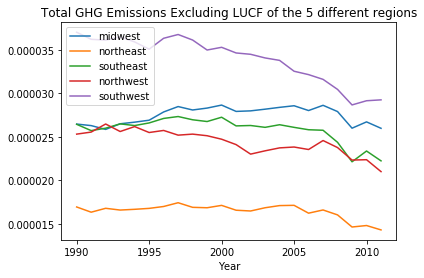

```python
ax=plt.gca()
groups=region_data_norm.groupby('region')
groups.get_group('midwest').plot.line(x='Year',y='Total GHG Emissions Excluding LUCF (MtCO2e)',ax=ax, label='midwest')
groups.get_group('northeast').plot.line(x='Year',y='Total GHG Emissions Excluding LUCF (MtCO2e)',ax=ax,label='northeast')
groups.get_group('southeast').plot.line(x='Year',y='Total GHG Emissions Excluding LUCF (MtCO2e)',ax=ax,label='southeast')
groups.get_group('northwest').plot.line(x='Year',y='Total GHG Emissions Excluding LUCF (MtCO2e)',ax=ax, label='northwest')
groups.get_group('southwest').plot.line(x='Year',y='Total GHG Emissions Excluding LUCF (MtCO2e)',ax=ax,label='southwest',title='Total GHG Emissions Excluding LUCF of the 5 different regions')
```

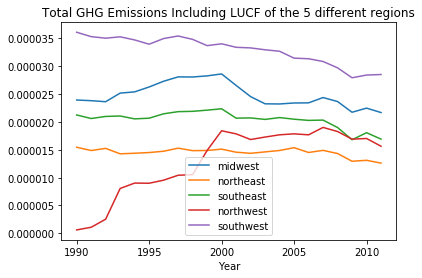

```python
ax=plt.gca()
groups=region_data_norm.groupby('region')
groups.get_group('midwest').plot.line(x='Year',y='Total GHG Emissions Including LUCF (MtCO2e',ax=ax, label='midwest')
groups.get_group('northeast').plot.line(x='Year',y='Total GHG Emissions Including LUCF (MtCO2e',ax=ax,label='northeast')
groups.get_group('southeast').plot.line(x='Year',y='Total GHG Emissions Including LUCF (MtCO2e',ax=ax,label='southeast')
groups.get_group('northwest').plot.line(x='Year',y='Total GHG Emissions Including LUCF (MtCO2e',ax=ax, label='northwest')
groups.get_group('southwest').plot.line(x='Year',y='Total GHG Emissions Including LUCF (MtCO2e',ax=ax,label='southwest',title='Total GHG Emissions Including LUCF of the 5 different regions')
```

```python
region_Year_sector_norm=region_data_norm.drop(["gas","Total GHG Emissions Excluding LUCF (MtCO2e)","Total GHG Emissions Including LUCF (MtCO2e","Population (People)"],axis=1)
region_Year_sector_norm=region_Year_sector_norm.groupby(['region','sector']).agg({'MtCO2e emmisions by sector':'mean'}).reset_index()
region_Year_sector.head()
```

|  | region | sector | MtCO2e emmisions by sector |
| --- | --- | --- | --- |
| 0 | midwest | Agriculture (MtCO2e) | 159.680978 |
| 1 | midwest | Bunker Fuels (MtCO2e) | 0.000982 |
| 2 | midwest | Energy (MtCO2e) | 1431.448447 |
| 3 | midwest | Industrial Processes (MtCO2e) | 65.004013 |
| 4 | midwest | Land Use and Forestry (MtCO2e) | -161.851542 |

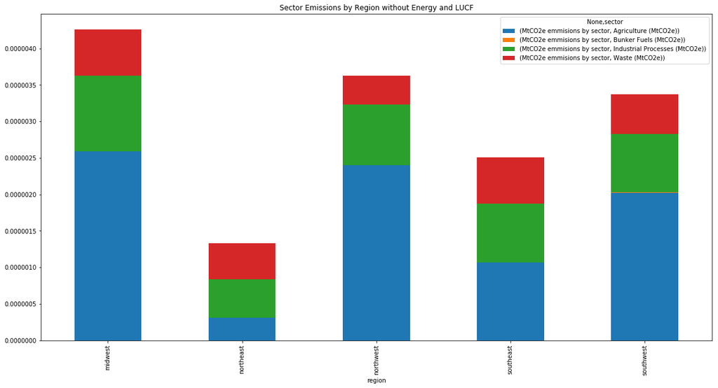

```python
region_Year_sector_norm[(region_Year_sector_norm['sector']!= 'Land Use and Forestry (MtCO2e)') &(region_Year_sector_norm['sector']!= 'Energy (MtCO2e)')].pivot_table(index='region',columns='sector').plot.bar(stacked=True,figsize=(20,10), title='Sector Emissions by Region without Energy and LUCF')
```

As you can tell, the normalization by population helped make it easier to compare the contribution of each industry sector to each region. It also helps depict the fact that throughout the US, Agriculture is producing the most Greenhouse gasses after energy. The impact of agriculture is extremely substantial in almost every region. This goes to show further the impact of how we use land.

### Question 4: How does each regions total emissions compare/contribute to the total emissions of the US from dataset 2 (with and without LUCF)

Although this gives us good insight on the emissions in each region, I am curious how each region's emissions would compare to the emissions of the US as a whole. I will use dataset 2 in order to make these comparisons.

I am going to explore how much of an impact Land Use and Forestry has on lessening the Emissions both across the US and in each region. I would expect for the emissions to be drastically lessened in regions such as the Midwest, but not as impacted by LUCF in regions such as the Northeast.I expect for the US emissions overall to not be drastically impacted.

I am also going to look at what proportion of the US's total emissions (found in dataset 2) each region makes up. I am predicting that the Northeast and the southeast will make up majority of the total US emissions.

As we saw above, the region data normalized by population was much more informative. However, I want to analyze how each regions total emissions contribute to the US's total emissions. Thus, I will not be using the normalized data.

```python
region_data['Year'].unique()
```

```
array([1990, 1991, 1992, 1993, 1994, 1995, 1996, 1997, 1998, 1999, 2000,
       2001, 2002, 2003, 2004, 2005, 2006, 2007, 2008, 2009, 2010, 2011])
```

```python
data2['Year'].unique()
```

```
array([2000, 2005, 2010, 2011, 2015, 2020, 2025, 2030], dtype=object)
```

As you can tell, the US data is much more limited in years than the regions data. In order to have consistency, we must restrict both data to the same years: 2000, 2005, 2010, 2011.

```python
data2=data2[data2['Year'].isin([2000,2005,2010,2011])]
region_data=region_data[region_data['Year'].isin([2000,2005,2010,2011])]
region_data
```

|  | region | Year | sector | gas | Total GHG Emissions Excluding LUCF (MtCO2e) | Total GHG Emissions Including LUCF (MtCO2e | MtCO2e emmisions by sector | State GDP (Million US$ (chained 1997/2005)) | Population (People) | Total Energy Use (Thous. tonnes oil eq. (ktoe)) | total emmisions by gas |
| --- | --- | --- | --- | --- | --- | --- | --- | --- | --- | --- | --- |
| 240 | midwest | 2000 | Agriculture (MtCO2e) | Total CH4 (MtCO2e) | 1776.276788 | 1775.776322 | 154.792176 | 2400674 | 62021767 | 564074.643871 | 106.246298 |
| 241 | midwest | 2000 | Agriculture (MtCO2e) | Total CO2 (excluding LUCF) (MtCO2e) | 1776.276788 | 1775.776322 | 154.792176 | 2400674 | 62021767 | 564074.643871 | 1524.668613 |
| 242 | midwest | 2000 | Agriculture (MtCO2e) | Total F-Gas (MtCO2e) | 1776.276788 | 1775.776322 | 154.792176 | 2400674 | 62021767 | 564074.643871 | 21.407679 |
| 243 | midwest | 2000 | Agriculture (MtCO2e) | Total N2O (MtCO2e) | 1776.276788 | 1775.776322 | 154.792176 | 2400674 | 62021767 | 564074.643871 | 123.953615 |
| 244 | midwest | 2000 | Bunker Fuels (MtCO2e) | Total CH4 (MtCO2e) | 1776.276788 | 1775.776322 | 0.000583 | 2400674 | 62021767 | 564074.643871 | 106.246298 |
| 245 | midwest | 2000 | Bunker Fuels (MtCO2e) | Total CO2 (excluding LUCF) (MtCO2e) | 1776.276788 | 1775.776322 | 0.000583 | 2400674 | 62021767 | 564074.643871 | 1524.668613 |
| 246 | midwest | 2000 | Bunker Fuels (MtCO2e) | Total F-Gas (MtCO2e) | 1776.276788 | 1775.776322 | 0.000583 | 2400674 | 62021767 | 564074.643871 | 21.407679 |
| 247 | midwest | 2000 | Bunker Fuels (MtCO2e) | Total N2O (MtCO2e) | 1776.276788 | 1775.776322 | 0.000583 | 2400674 | 62021767 | 564074.643871 | 123.953615 |
| 248 | midwest | 2000 | Energy (MtCO2e) | Total CH4 (MtCO2e) | 1776.276788 | 1775.776322 | 1493.056766 | 2400674 | 62021767 | 564074.643871 | 106.246298 |
| 249 | midwest | 2000 | Energy (MtCO2e) | Total CO2 (excluding LUCF) (MtCO2e) | 1776.276788 | 1775.776322 | 1493.056766 | 2400674 | 62021767 | 564074.643871 | 1524.668613 |
| 250 | midwest | 2000 | Energy (MtCO2e) | Total F-Gas (MtCO2e) | 1776.276788 | 1775.776322 | 1493.056766 | 2400674 | 62021767 | 564074.643871 | 21.407679 |
| 251 | midwest | 2000 | Energy (MtCO2e) | Total N2O (MtCO2e) | 1776.276788 | 1775.776322 | 1493.056766 | 2400674 | 62021767 | 564074.643871 | 123.953615 |
| 252 | midwest | 2000 | Industrial Processes (MtCO2e) | Total CH4 (MtCO2e) | 1776.276788 | 1775.776322 | 90.732903 | 2400674 | 62021767 | 564074.643871 | 106.246298 |
| 253 | midwest | 2000 | Industrial Processes (MtCO2e) | Total CO2 (excluding LUCF) (MtCO2e) | 1776.276788 | 1775.776322 | 90.732903 | 2400674 | 62021767 | 564074.643871 | 1524.668613 |
| 254 | midwest | 2000 | Industrial Processes (MtCO2e) | Total F-Gas (MtCO2e) | 1776.276788 | 1775.776322 | 90.732903 | 2400674 | 62021767 | 564074.643871 | 21.407679 |
| 255 | midwest | 2000 | Industrial Processes (MtCO2e) | Total N2O (MtCO2e) | 1776.276788 | 1775.776322 | 90.732903 | 2400674 | 62021767 | 564074.643871 | 123.953615 |
| 256 | midwest | 2000 | Land Use and Forestry (MtCO2e) | Total CH4 (MtCO2e) | 1776.276788 | 1775.776322 | -0.500467 | 2400674 | 62021767 | 564074.643871 | 106.246298 |
| 257 | midwest | 2000 | Land Use and Forestry (MtCO2e) | Total CO2 (excluding LUCF) (MtCO2e) | 1776.276788 | 1775.776322 | -0.500467 | 2400674 | 62021767 | 564074.643871 | 1524.668613 |
| 258 | midwest | 2000 | Land Use and Forestry (MtCO2e) | Total F-Gas (MtCO2e) | 1776.276788 | 1775.776322 | -0.500467 | 2400674 | 62021767 | 564074.643871 | 21.407679 |
| 259 | midwest | 2000 | Land Use and Forestry (MtCO2e) | Total N2O (MtCO2e) | 1776.276788 | 1775.776322 | -0.500467 | 2400674 | 62021767 | 564074.643871 | 123.953615 |
| 260 | midwest | 2000 | Waste (MtCO2e) | Total CH4 (MtCO2e) | 1776.276788 | 1775.776322 | 37.694360 | 2400674 | 62021767 | 564074.643871 | 106.246298 |
| 261 | midwest | 2000 | Waste (MtCO2e) | Total CO2 (excluding LUCF) (MtCO2e) | 1776.276788 | 1775.776322 | 37.694360 | 2400674 | 62021767 | 564074.643871 | 1524.668613 |
| 262 | midwest | 2000 | Waste (MtCO2e) | Total F-Gas (MtCO2e) | 1776.276788 | 1775.776322 | 37.694360 | 2400674 | 62021767 | 564074.643871 | 21.407679 |
| 263 | midwest | 2000 | Waste (MtCO2e) | Total N2O (MtCO2e) | 1776.276788 | 1775.776322 | 37.694360 | 2400674 | 62021767 | 564074.643871 | 123.953615 |
| 360 | midwest | 2005 | Agriculture (MtCO2e) | Total CH4 (MtCO2e) | 1805.553503 | 1480.094927 | 163.705830 | 2549646 | 63214882 | 575383.962180 | 109.594592 |
| 361 | midwest | 2005 | Agriculture (MtCO2e) | Total CO2 (excluding LUCF) (MtCO2e) | 1805.553503 | 1480.094927 | 163.705830 | 2549646 | 63214882 | 575383.962180 | 1549.002713 |
| 362 | midwest | 2005 | Agriculture (MtCO2e) | Total F-Gas (MtCO2e) | 1805.553503 | 1480.094927 | 163.705830 | 2549646 | 63214882 | 575383.962180 | 24.585936 |
| 363 | midwest | 2005 | Agriculture (MtCO2e) | Total N2O (MtCO2e) | 1805.553503 | 1480.094927 | 163.705830 | 2549646 | 63214882 | 575383.962180 | 122.364291 |
| 364 | midwest | 2005 | Bunker Fuels (MtCO2e) | Total CH4 (MtCO2e) | 1805.553503 | 1480.094927 | 0.005970 | 2549646 | 63214882 | 575383.962180 | 109.594592 |
| 365 | midwest | 2005 | Bunker Fuels (MtCO2e) | Total CO2 (excluding LUCF) (MtCO2e) | 1805.553503 | 1480.094927 | 0.005970 | 2549646 | 63214882 | 575383.962180 | 1549.002713 |
| ... | ... | ... | ... | ... | ... | ... | ... | ... | ... | ... | ... |
| 2610 | southwest | 2010 | Land Use and Forestry (MtCO2e) | Total F-Gas (MtCO2e) | 1091.976718 | 1065.550266 | -26.426452 | 1540986 | 37477742 | 393399.016310 | 16.775904 |
| 2611 | southwest | 2010 | Land Use and Forestry (MtCO2e) | Total N2O (MtCO2e) | 1091.976718 | 1065.550266 | -26.426452 | 1540986 | 37477742 | 393399.016310 | 30.408323 |
| 2612 | southwest | 2010 | Waste (MtCO2e) | Total CH4 (MtCO2e) | 1091.976718 | 1065.550266 | 17.618051 | 1540986 | 37477742 | 393399.016310 | 113.357431 |
| 2613 | southwest | 2010 | Waste (MtCO2e) | Total CO2 (excluding LUCF) (MtCO2e) | 1091.976718 | 1065.550266 | 17.618051 | 1540986 | 37477742 | 393399.016310 | 931.313836 |
| 2614 | southwest | 2010 | Waste (MtCO2e) | Total F-Gas (MtCO2e) | 1091.976718 | 1065.550266 | 17.618051 | 1540986 | 37477742 | 393399.016310 | 16.775904 |
| 2615 | southwest | 2010 | Waste (MtCO2e) | Total N2O (MtCO2e) | 1091.976718 | 1065.550266 | 17.618051 | 1540986 | 37477742 | 393399.016310 | 30.408323 |
| 2616 | southwest | 2011 | Agriculture (MtCO2e) | Total CH4 (MtCO2e) | 1109.992795 | 1083.057384 | 62.185055 | 1586783 | 37961930 | 401194.102400 | 112.371048 |
| 2617 | southwest | 2011 | Agriculture (MtCO2e) | Total CO2 (excluding LUCF) (MtCO2e) | 1109.992795 | 1083.057384 | 62.185055 | 1586783 | 37961930 | 401194.102400 | 953.870525 |
| 2618 | southwest | 2011 | Agriculture (MtCO2e) | Total F-Gas (MtCO2e) | 1109.992795 | 1083.057384 | 62.185055 | 1586783 | 37961930 | 401194.102400 | 17.505875 |
| 2619 | southwest | 2011 | Agriculture (MtCO2e) | Total N2O (MtCO2e) | 1109.992795 | 1083.057384 | 62.185055 | 1586783 | 37961930 | 401194.102400 | 26.135466 |
| 2620 | southwest | 2011 | Bunker Fuels (MtCO2e) | Total CH4 (MtCO2e) | 1109.992795 | 1083.057384 | 0.109881 | 1586783 | 37961930 | 401194.102400 | 112.371048 |
| 2621 | southwest | 2011 | Bunker Fuels (MtCO2e) | Total CO2 (excluding LUCF) (MtCO2e) | 1109.992795 | 1083.057384 | 0.109881 | 1586783 | 37961930 | 401194.102400 | 953.870525 |
| 2622 | southwest | 2011 | Bunker Fuels (MtCO2e) | Total F-Gas (MtCO2e) | 1109.992795 | 1083.057384 | 0.109881 | 1586783 | 37961930 | 401194.102400 | 17.505875 |
| 2623 | southwest | 2011 | Bunker Fuels (MtCO2e) | Total N2O (MtCO2e) | 1109.992795 | 1083.057384 | 0.109881 | 1586783 | 37961930 | 401194.102400 | 26.135466 |
| 2624 | southwest | 2011 | Energy (MtCO2e) | Total CH4 (MtCO2e) | 1109.992795 | 1083.057384 | 998.358392 | 1586783 | 37961930 | 401194.102400 | 112.371048 |
| 2625 | southwest | 2011 | Energy (MtCO2e) | Total CO2 (excluding LUCF) (MtCO2e) | 1109.992795 | 1083.057384 | 998.358392 | 1586783 | 37961930 | 401194.102400 | 953.870525 |
| 2626 | southwest | 2011 | Energy (MtCO2e) | Total F-Gas (MtCO2e) | 1109.992795 | 1083.057384 | 998.358392 | 1586783 | 37961930 | 401194.102400 | 17.505875 |
| 2627 | southwest | 2011 | Energy (MtCO2e) | Total N2O (MtCO2e) | 1109.992795 | 1083.057384 | 998.358392 | 1586783 | 37961930 | 401194.102400 | 26.135466 |
| 2628 | southwest | 2011 | Industrial Processes (MtCO2e) | Total CH4 (MtCO2e) | 1109.992795 | 1083.057384 | 31.682648 | 1586783 | 37961930 | 401194.102400 | 112.371048 |
| 2629 | southwest | 2011 | Industrial Processes (MtCO2e) | Total CO2 (excluding LUCF) (MtCO2e) | 1109.992795 | 1083.057384 | 31.682648 | 1586783 | 37961930 | 401194.102400 | 953.870525 |
| 2630 | southwest | 2011 | Industrial Processes (MtCO2e) | Total F-Gas (MtCO2e) | 1109.992795 | 1083.057384 | 31.682648 | 1586783 | 37961930 | 401194.102400 | 17.505875 |
| 2631 | southwest | 2011 | Industrial Processes (MtCO2e) | Total N2O (MtCO2e) | 1109.992795 | 1083.057384 | 31.682648 | 1586783 | 37961930 | 401194.102400 | 26.135466 |
| 2632 | southwest | 2011 | Land Use and Forestry (MtCO2e) | Total CH4 (MtCO2e) | 1109.992795 | 1083.057384 | -26.935410 | 1586783 | 37961930 | 401194.102400 | 112.371048 |
| 2633 | southwest | 2011 | Land Use and Forestry (MtCO2e) | Total CO2 (excluding LUCF) (MtCO2e) | 1109.992795 | 1083.057384 | -26.935410 | 1586783 | 37961930 | 401194.102400 | 953.870525 |
| 2634 | southwest | 2011 | Land Use and Forestry (MtCO2e) | Total F-Gas (MtCO2e) | 1109.992795 | 1083.057384 | -26.935410 | 1586783 | 37961930 | 401194.102400 | 17.505875 |
| 2635 | southwest | 2011 | Land Use and Forestry (MtCO2e) | Total N2O (MtCO2e) | 1109.992795 | 1083.057384 | -26.935410 | 1586783 | 37961930 | 401194.102400 | 26.135466 |
| 2636 | southwest | 2011 | Waste (MtCO2e) | Total CH4 (MtCO2e) | 1109.992795 | 1083.057384 | 17.656818 | 1586783 | 37961930 | 401194.102400 | 112.371048 |
| 2637 | southwest | 2011 | Waste (MtCO2e) | Total CO2 (excluding LUCF) (MtCO2e) | 1109.992795 | 1083.057384 | 17.656818 | 1586783 | 37961930 | 401194.102400 | 953.870525 |
| 2638 | southwest | 2011 | Waste (MtCO2e) | Total F-Gas (MtCO2e) | 1109.992795 | 1083.057384 | 17.656818 | 1586783 | 37961930 | 401194.102400 | 17.505875 |
| 2639 | southwest | 2011 | Waste (MtCO2e) | Total N2O (MtCO2e) | 1109.992795 | 1083.057384 | 17.656818 | 1586783 | 37961930 | 401194.102400 | 26.135466 |

480 rows × 11 columns

I now will drop unnecessary columns and rows from the region data, and then combine the datasets.

```python
compare_data=region_data[['region','Year','Total GHG Emissions Including LUCF (MtCO2e','Total GHG Emissions Excluding LUCF (MtCO2e)']]
```

```python
compare_data=compare_data.groupby(['Year','region']).aggregate({'region':'first','Year':'first','Total GHG Emissions Including LUCF (MtCO2e':'first','Total GHG Emissions Excluding LUCF (MtCO2e)':'first'})
compare_data=compare_data.drop(['region','Year'],axis=1).reset_index()
```

```python
compare_data
```

|  | Year | region | Total GHG Emissions Including LUCF (MtCO2e | Total GHG Emissions Excluding LUCF (MtCO2e) |
| --- | --- | --- | --- | --- |
| 0 | 2000 | midwest | 1775.776322 | 1776.276788 |
| 1 | 2000 | northeast | 724.801619 | 820.135892 |
| 2 | 2000 | northwest | 221.764854 | 297.531731 |
| 3 | 2000 | southeast | 1572.632365 | 1914.664776 |
| 4 | 2000 | southwest | 1068.345498 | 1107.075545 |
| 5 | 2005 | midwest | 1480.094927 | 1805.553503 |
| 6 | 2005 | northeast | 750.983038 | 835.572392 |
| 7 | 2005 | northwest | 227.935083 | 303.758915 |
| 8 | 2005 | southeast | 1537.480821 | 1955.788158 |
| 9 | 2005 | southwest | 1073.022533 | 1109.142535 |
| 10 | 2010 | midwest | 1446.726251 | 1717.992532 |
| 11 | 2010 | northeast | 651.983313 | 735.310914 |
| 12 | 2010 | northwest | 233.561254 | 306.511131 |
| 13 | 2010 | southeast | 1436.314322 | 1856.056807 |
| 14 | 2010 | southwest | 1065.550266 | 1091.976718 |
| 15 | 2011 | midwest | 1398.968607 | 1674.527143 |
| 16 | 2011 | northeast | 629.700639 | 713.365860 |
| 17 | 2011 | northwest | 216.579098 | 290.518675 |
| 18 | 2011 | southeast | 1356.455694 | 1781.478633 |
| 19 | 2011 | southwest | 1083.057384 | 1109.992795 |

```python
data2.dtypes
```

```
region                                         object
Year                                           object
Total GHG Emissions Including LUCF (MtCO2e     object
Total GHG Emissions Excluding LUCF (MtCO2e)    object
dtype: object
```

Before we can merge, we have to convert the Year and the Total GHG emissions columns into a data types int

```python
data2['Total GHG Emissions Including LUCF (MtCO2e']=pd.to_numeric(data2['Total GHG Emissions Including LUCF (MtCO2e'])
data2['Year']=pd.to_numeric(data2['Year'])
data2['Total GHG Emissions Excluding LUCF (MtCO2e)']=pd.to_numeric(data2['Total GHG Emissions Including LUCF (MtCO2e'])
```

```python
regions_US=compare_data.merge(data2, how="outer")
```

```python
regions_US
```

|  | Year | region | Total GHG Emissions Including LUCF (MtCO2e | Total GHG Emissions Excluding LUCF (MtCO2e) |
| --- | --- | --- | --- | --- |
| 0 | 2000 | midwest | 1775.776322 | 1776.276788 |
| 1 | 2000 | northeast | 724.801619 | 820.135892 |
| 2 | 2000 | northwest | 221.764854 | 297.531731 |
| 3 | 2000 | southeast | 1572.632365 | 1914.664776 |
| 4 | 2000 | southwest | 1068.345498 | 1107.075545 |
| 5 | 2005 | midwest | 1480.094927 | 1805.553503 |
| 6 | 2005 | northeast | 750.983038 | 835.572392 |
| 7 | 2005 | northwest | 227.935083 | 303.758915 |
| 8 | 2005 | southeast | 1537.480821 | 1955.788158 |
| 9 | 2005 | southwest | 1073.022533 | 1109.142535 |
| 10 | 2010 | midwest | 1446.726251 | 1717.992532 |
| 11 | 2010 | northeast | 651.983313 | 735.310914 |
| 12 | 2010 | northwest | 233.561254 | 306.511131 |
| 13 | 2010 | southeast | 1436.314322 | 1856.056807 |
| 14 | 2010 | southwest | 1065.550266 | 1091.976718 |
| 15 | 2011 | midwest | 1398.968607 | 1674.527143 |
| 16 | 2011 | northeast | 629.700639 | 713.365860 |
| 17 | 2011 | northwest | 216.579098 | 290.518675 |
| 18 | 2011 | southeast | 1356.455694 | 1781.478633 |
| 19 | 2011 | southwest | 1083.057384 | 1109.992795 |
| 20 | 2000 | United States | 7076.000000 | 7076.000000 |
| 21 | 2005 | United States | 7195.000000 | 7195.000000 |
| 22 | 2010 | United States | 6812.000000 | 6812.000000 |
| 23 | 2011 | United States | 6702.000000 | 6702.000000 |

I first want to assess what kind of impact LUCF is having on each region, including the US.

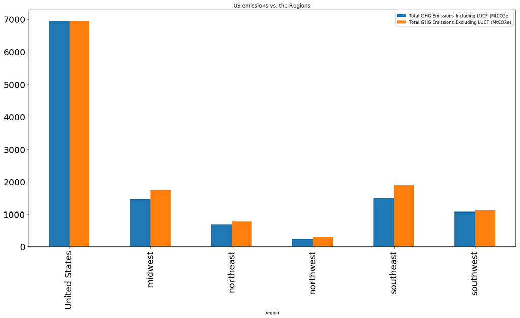

```python
regions_US.groupby(['region']).median().plot.bar(y=['Total GHG Emissions Including LUCF (MtCO2e','Total GHG Emissions Excluding LUCF (MtCO2e)'],figsize=(20,10),fontsize=20, title="US emissions vs. the Regions")
```

I now want to create a pie chart to represent what proportion of US GHG emissions each region made up for each of the available years.

```python
groups=regions_US.groupby('Year')
```

```python
G1=groups.get_group(2000)
G2=groups.get_group(2005)
G3=groups.get_group(2010)
G4=groups.get_group(2011)
```

```python
G1
```

|  | Year | region | Total GHG Emissions Including LUCF (MtCO2e | Total GHG Emissions Excluding LUCF (MtCO2e) |
| --- | --- | --- | --- | --- |
| 0 | 2000 | midwest | 1775.776322 | 1776.276788 |
| 1 | 2000 | northeast | 724.801619 | 820.135892 |
| 2 | 2000 | northwest | 221.764854 | 297.531731 |
| 3 | 2000 | southeast | 1572.632365 | 1914.664776 |
| 4 | 2000 | southwest | 1068.345498 | 1107.075545 |
| 20 | 2000 | United States | 7076.000000 | 7076.000000 |

```python
US=7076.000000
G1['Total GHG Emissions Including LUCF (MtCO2e']=G1['Total GHG Emissions Including LUCF (MtCO2e']/US
G1['Total GHG Emissions Excluding LUCF (MtCO2e)']=G1['Total GHG Emissions Excluding LUCF (MtCO2e)']/US
```

```python
G1
```

|  | Year | region | Total GHG Emissions Including LUCF (MtCO2e | Total GHG Emissions Excluding LUCF (MtCO2e) |
| --- | --- | --- | --- | --- |
| 0 | 2000 | midwest | 0.250958 | 0.251028 |
| 1 | 2000 | northeast | 0.102431 | 0.115904 |
| 2 | 2000 | northwest | 0.031340 | 0.042048 |
| 3 | 2000 | southeast | 0.222249 | 0.270586 |
| 4 | 2000 | southwest | 0.150982 | 0.156455 |
| 20 | 2000 | United States | 1.000000 | 1.000000 |

```python
G2
```

|  | Year | region | Total GHG Emissions Including LUCF (MtCO2e | Total GHG Emissions Excluding LUCF (MtCO2e) |
| --- | --- | --- | --- | --- |
| 5 | 2005 | midwest | 1480.094927 | 1805.553503 |
| 6 | 2005 | northeast | 750.983038 | 835.572392 |
| 7 | 2005 | northwest | 227.935083 | 303.758915 |
| 8 | 2005 | southeast | 1537.480821 | 1955.788158 |
| 9 | 2005 | southwest | 1073.022533 | 1109.142535 |
| 21 | 2005 | United States | 7195.000000 | 7195.000000 |

```python
US=7195.000000
G2['Total GHG Emissions Including LUCF (MtCO2e']=G2['Total GHG Emissions Including LUCF (MtCO2e']/US
G2['Total GHG Emissions Excluding LUCF (MtCO2e)']=G2['Total GHG Emissions Excluding LUCF (MtCO2e)']/US
```

```python
G3
```

|  | Year | region | Total GHG Emissions Including LUCF (MtCO2e | Total GHG Emissions Excluding LUCF (MtCO2e) |
| --- | --- | --- | --- | --- |
| 10 | 2010 | midwest | 1446.726251 | 1717.992532 |
| 11 | 2010 | northeast | 651.983313 | 735.310914 |
| 12 | 2010 | northwest | 233.561254 | 306.511131 |
| 13 | 2010 | southeast | 1436.314322 | 1856.056807 |
| 14 | 2010 | southwest | 1065.550266 | 1091.976718 |
| 22 | 2010 | United States | 6812.000000 | 6812.000000 |

```python
US=6812.000000
G3['Total GHG Emissions Including LUCF (MtCO2e']=G3['Total GHG Emissions Including LUCF (MtCO2e']/US
G3['Total GHG Emissions Excluding LUCF (MtCO2e)']=G3['Total GHG Emissions Excluding LUCF (MtCO2e)']/US
```

```python
G4
```

|  | Year | region | Total GHG Emissions Including LUCF (MtCO2e | Total GHG Emissions Excluding LUCF (MtCO2e) |
| --- | --- | --- | --- | --- |
| 15 | 2011 | midwest | 1398.968607 | 1674.527143 |
| 16 | 2011 | northeast | 629.700639 | 713.365860 |
| 17 | 2011 | northwest | 216.579098 | 290.518675 |
| 18 | 2011 | southeast | 1356.455694 | 1781.478633 |
| 19 | 2011 | southwest | 1083.057384 | 1109.992795 |
| 23 | 2011 | United States | 6702.000000 | 6702.000000 |

```python
US=6702.000000
G4['Total GHG Emissions Including LUCF (MtCO2e']=G4['Total GHG Emissions Including LUCF (MtCO2e']/US
G4['Total GHG Emissions Excluding LUCF (MtCO2e)']=G4['Total GHG Emissions Excluding LUCF (MtCO2e)']/US
```

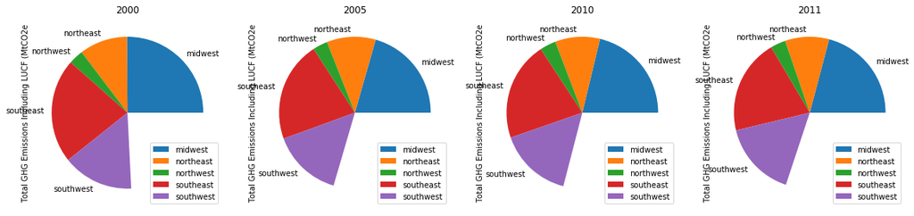

```python
fig, ax = plt.subplots(1, 4, figsize=(20,40))
G1.set_index('region').drop('United States').plot.pie(y='Total GHG Emissions Including LUCF (MtCO2e',title = '2000',ax=ax[0])
G2.set_index('region').drop('United States').plot.pie(y='Total GHG Emissions Including LUCF (MtCO2e',title = '2005',ax=ax[1])
G3.set_index('region').drop('United States').plot.pie(y='Total GHG Emissions Including LUCF (MtCO2e',title = '2010',ax=ax[2])
G4.set_index('region').drop('United States').plot.pie(y='Total GHG Emissions Including LUCF (MtCO2e',title = '2011',ax=ax[3])
```

As you can see each year, the southeast and the midwest are the largest contributers to US GHG emissions. Note that for some of the years, there are some GHG emissions that are unaccounted for by the region data, this is represented by the blank portions of the pie charts. Lets now take a look at the porportion without LUCF.

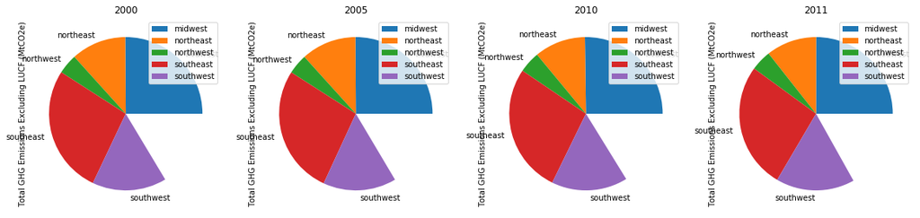

```python
fig, ax = plt.subplots(1, 4, figsize=(20,40))
G1.set_index('region').drop('United States').plot.pie(y='Total GHG Emissions Excluding LUCF (MtCO2e)',title = '2000',ax=ax[0])
G2.set_index('region').drop('United States').plot.pie(y='Total GHG Emissions Excluding LUCF (MtCO2e)',title = '2005',ax=ax[1])
G3.set_index('region').drop('United States').plot.pie(y='Total GHG Emissions Excluding LUCF (MtCO2e)',title = '2010',ax=ax[2])
G4.set_index('region').drop('United States').plot.pie(y='Total GHG Emissions Excluding LUCF (MtCO2e)',title = '2011',ax=ax[3])
```

# Conclusion

In conclusion, EVERYONE GO PLANT TREES!